# Project

### For R beginners

New chunk *Ctrl+Alt+I*

Execute chunk *Ctrl+Shift+Enter*

Execute all chunks *Ctrl+Alt+R*

HTML preview *Ctrl+Shift+K*

# Library preparations

```r
library(readr)
library(dplyr)
library(tidyverse)
library(ggplot2)
library(reshape2)
library(stats)
library(tm)
library(text2vec)
library(textstem)
```

# Data Import

```r
data_posts <- read.csv("~/4year/2semester/dtII/CSVs/HEIs.csv",
                 colClasses = c(tweet_id = "character"))

# Modifying created_at type so that attribute can be used more easily
data_posts$created_at <- as.POSIXct(data_posts$created_at,
                              format= "%Y-%m-%dT%H:%M:%S", tz="UTC")

#View(data)
summary(data_posts)
```

```
      id              tweet_id             text               type           bookmark_count    favorite_count     retweet_count      reply_count
 Length:11728       Length:11728       Length:11728       Length:11728       Min.   :  0.000   Min.   :    0.00   Min.   :   0.00   Min.   :   0.000
 Class :character   Class :character   Class :character   Class :character   1st Qu.:  0.000   1st Qu.:    7.00   1st Qu.:   2.00   1st Qu.:   0.000
 Mode  :character   Mode  :character   Mode  :character   Mode  :character   Median :  0.000   Median :   20.00   Median :   5.00   Median :   1.000
                                                                             Mean   :  1.543   Mean   :   60.67   Mean   :  10.62   Mean   :   3.888
                                                                             3rd Qu.:  1.000   3rd Qu.:   57.00   3rd Qu.:  11.00   3rd Qu.:   3.000
                                                                             Max.   :418.000   Max.   :41655.00   Max.   :4214.00   Max.   :2317.000

   view_count        created_at                       hashtags             urls            media_type         media_urls
 Min.   :      5   Min.   :2022-08-01 03:05:11.00   Length:11728       Length:11728       Length:11728       Length:11728
 1st Qu.:   2643   1st Qu.:2022-10-19 12:56:27.00   Class :character   Class :character   Class :character   Class :character
 Median :   6240   Median :2023-01-29 08:26:30.00   Mode  :character   Mode  :character   Mode  :character   Mode  :character
 Mean   :  14182   Mean   :2023-01-30 07:39:34.96
 3rd Qu.:  16058   3rd Qu.:2023-05-05 14:16:43.25
 Max.   :7604544   Max.   :2023-08-31 20:50:01.00
 NA's   :4840
```

# Initial Data Preparation

```r
# Count of how many entries each HEI has
number_interactions <- data_posts %>%
              group_by(id) %>% summarise(count = n())

number_interactions
```

| id | count |
| --- | --- |
| complutense.csv | 1 |
| duke.csv | 690 |
| epfl.csv | 593 |
| goe.csv | 149 |
| harvard.csv | 2016 |
| leicester.csv | 1234 |
| manchester.csv | 1385 |
| mit.csv | 1046 |
| sb.csv | 713 |
| stanford.csv | 349 |

[output cut: 3 more lines]

# Since complutense only has 1 entry we can’t learn anything from it, so we removed it

```r
data_posts <- data_posts[data_posts$id != "complutense.csv", ]
```

# Visualization of all posts, just tweets and just replies

```r
number_posts <- data_posts %>%
              group_by(id) %>% summarise(posts = n())

number_tweets <- data_posts[data_posts$type == "Tweet", ] %>%
              group_by(id) %>% summarise(tweets = n())

number_replies <- data_posts[data_posts$type == "Reply", ] %>%
              group_by(id) %>% summarise(replies = n())

print(number_posts)
```

| id | posts |
| --- | --- |
| duke.csv | 690 |
| epfl.csv | 593 |
| goe.csv | 149 |
| harvard.csv | 2016 |
| leicester.csv | 1234 |
| manchester.csv | 1385 |
| mit.csv | 1046 |
| sb.csv | 713 |
| stanford.csv | 349 |
| trinity.csv | 962 |

[output cut: 2 more lines]

```r
print(number_tweets)
```

| id | tweets |
| --- | --- |
| duke.csv | 617 |
| epfl.csv | 409 |
| goe.csv | 105 |
| harvard.csv | 2014 |
| leicester.csv | 1125 |
| manchester.csv | 632 |
| mit.csv | 1046 |
| sb.csv | 507 |
| stanford.csv | 315 |
| trinity.csv | 903 |

[output cut: 2 more lines]

```r
print(number_replies)
```

| id | replies |
| --- | --- |
| duke.csv | 73 |
| epfl.csv | 8 |
| goe.csv | 3 |
| harvard.csv | 2 |
| leicester.csv | 109 |
| manchester.csv | 753 |
| sb.csv | 71 |
| stanford.csv | 34 |
| trinity.csv | 59 |
| wv.csv | 215 |

[output cut: 1 more lines]

# Calculating the percentage of tweets and replies based on all posts

```r
# Merging the counts of tweets and replies with the count of posts
data_ratio <- merge(number_posts, number_tweets, by = "id", all = TRUE)
data_ratio <- merge(data_ratio, number_replies, by = "id", all = TRUE)


data_ratio$percentage_tweets <- round(((data_ratio$tweets / data_ratio$posts) * 100), 2)
data_ratio$percentage_replies <- round(((data_ratio$replies / data_ratio$posts) * 100), 2)

data_ratio <- data_ratio[, c("id", "percentage_tweets", "percentage_replies")]

data_ratio$percentage_replies[is.na(data_ratio$percentage_replies)] <- 0

print(data_ratio)
```

| id | percentage_tweets | percentage_replies |
| --- | --- | --- |
| duke.csv | 89.42 | 10.58 |
| epfl.csv | 68.97 | 1.35 |
| goe.csv | 70.47 | 2.01 |
| harvard.csv | 99.90 | 0.10 |
| leicester.csv | 91.17 | 8.83 |
| manchester.csv | 45.63 | 54.37 |
| mit.csv | 100.00 | 0.00 |
| sb.csv | 71.11 | 9.96 |
| stanford.csv | 90.26 | 9.74 |
| trinity.csv | 93.87 | 6.13 |

[output cut: 2 more lines]

# Function to visualize the number of NAs in all columns

```r
na_count <- function(){
  # Counting the number of NA values for each column
  na_count <- colSums(is.na(data_posts))

  # Creating a new data frame with the NA counts
  na_counts_table <- data.frame(Column = names(na_count), NA_Count = na_count)

  print(na_counts_table)
}
```

# Calculations of view, favourite, retweet and reply percentiles and visualization of NAs in all columns

```r
data_posts <- data_posts %>%
  group_by(id) %>%
  mutate(view_percentile = ntile(view_count, 100),
         favorite_percentile = ntile(favorite_count, 100),
         retweet_percentile = ntile(retweet_count, 100),
         reply_percentile = ntile(reply_count, 100)) %>%
  rowwise() %>%
  mutate(avg_percentile = round(mean(c(view_percentile, favorite_percentile, retweet_percentile, reply_percentile), na.rm = TRUE), 2))

na_count()
```

|  | Column | NA_Count |
| --- | --- | --- |
| id | id | 0 |
| tweet_id | tweet_id | 0 |
| text | text | 0 |
| type | type | 0 |
| bookmark_count | bookmark_count | 0 |
| favorite_count | favorite_count | 0 |
| retweet_count | retweet_count | 0 |
| reply_count | reply_count | 0 |
| view_count | view_count | 4839 |
| created_at | created_at | 0 |

[output cut: 9 more lines]

```r
data_percentile <- data_posts[, c("id", "view_percentile", "favorite_percentile", "retweet_percentile", "reply_percentile", "avg_percentile")]

print(data_percentile)
```

| id | view_percentile | favorite_percentile | retweet_percentile | reply_percentile | avg_percentile |
| --- | --- | --- | --- | --- | --- |
| yale.csv | 75 | 73 | 94 | 96 | 84.50 |
| yale.csv | 95 | 99 | 97 | 96 | 96.75 |
| yale.csv | 100 | 99 | 100 | 99 | 99.50 |
| yale.csv | 64 | 90 | 69 | 83 | 76.50 |
| yale.csv | 96 | 100 | 97 | 94 | 96.75 |
| yale.csv | 57 | 69 | 88 | 52 | 66.50 |
| yale.csv | 78 | 77 | 78 | 71 | 76.00 |
| yale.csv | 81 | 95 | 97 | 71 | 86.00 |
| yale.csv | 72 | 17 | 69 | 23 | 45.25 |
| yale.csv | 79 | 75 | 69 | 100 | 80.75 |

[output cut: 990 more lines]

# Calculation of the maximum number of views for each HEI

```r
max_view_counts <- tapply(data_posts$view_count, data_posts$id, max, na.rm = TRUE)

print(max_view_counts)
```

```
      duke.csv       epfl.csv        goe.csv    harvard.csv  leicester.csv manchester.csv        mit.csv         sb.csv   stanford.csv    trinity.csv
        307969         105095          15455        2982704          47838         317086        7604544         607498         222593         205333
        wv.csv       yale.csv
        109265         143108
```

# Removal of NAs

```r
# From view count
data_posts$view_count <- ifelse(
  is.na(data_posts$view_count),
  round(max_view_counts[data_posts$id] * (data_posts$avg_percentile / 100)),
  data_posts$view_count)

# From view percentile
data_posts$view_percentile <- ifelse(
  is.na(data_posts$view_percentile),
  data_posts$avg_percentile,
  data_posts$view_percentile)
```

# Visualization of NAs in all columns

```r
na_count()
```

|  | Column | NA_Count |
| --- | --- | --- |
| id | id | 0 |
| tweet_id | tweet_id | 0 |
| text | text | 0 |
| type | type | 0 |
| bookmark_count | bookmark_count | 0 |
| favorite_count | favorite_count | 0 |
| retweet_count | retweet_count | 0 |
| reply_count | reply_count | 0 |
| view_count | view_count | 0 |
| created_at | created_at | 0 |

[output cut: 9 more lines]

# Function to calculate average posts

```r
average_posts <- function(timeframe = "days"){
  # Calculation of the timeframe between earliest and latest post for each HEI
  date_range <- data_posts %>%
    group_by(id) %>%
    summarise(min_date = min(created_at),
              max_date = max(created_at)) %>%
    mutate(num_days = as.numeric(difftime(max_date, min_date, units = timeframe)))

  # Naming the column respecting the timeframe
  column_name <- paste0("avg_posts_per_", timeframe)

  # Calculation of the number of posts per day for each HEI
  posts_per_timeframe <- number_posts %>%
    left_join(date_range, by = "id") %>%
    mutate(!!column_name := round((posts / num_days), 2))

  print(posts_per_timeframe)
  return(posts_per_timeframe)
}
```

```r
posts_per_day <- average_posts()
```

| id | posts | min_date | max_date | num_days | avg_posts_per_days |
| --- | --- | --- | --- | --- | --- |
| duke.csv | 690 | 2022-08-01 10:47:25 | 2023-08-31 10:23:10 | 394.9832 | 1.75 |
| epfl.csv | 593 | 2022-08-02 11:22:16 | 2023-08-31 16:19:01 | 394.2061 | 1.50 |
| goe.csv | 149 | 2022-08-15 12:57:54 | 2023-08-31 12:03:17 | 380.9621 | 0.39 |
| harvard.csv | 2016 | 2022-08-01 10:21:01 | 2023-08-31 20:50:01 | 395.4368 | 5.10 |
| leicester.csv | 1234 | 2022-08-01 10:01:37 | 2023-08-31 17:35:36 | 395.3153 | 3.12 |
| manchester.csv | 1385 | 2022-08-01 11:30:00 | 2023-08-31 19:20:49 | 395.3270 | 3.50 |
| mit.csv | 1046 | 2022-08-01 03:05:11 | 2023-08-31 14:05:12 | 395.4583 | 2.65 |
| sb.csv | 713 | 2022-08-01 11:59:57 | 2023-08-31 20:00:15 | 395.3335 | 1.80 |
| stanford.csv | 349 | 2022-08-15 10:49:35 | 2023-08-30 13:39:13 | 380.1178 | 0.92 |
| trinity.csv | 962 | 2022-08-02 10:15:05 | 2023-08-31 14:52:31 | 394.1927 | 2.44 |

[output cut: 2 more lines]

```r
posts_per_week <- average_posts(timeframe = "weeks")
```

| id | posts | min_date | max_date | num_days | avg_posts_per_weeks |
| --- | --- | --- | --- | --- | --- |
| duke.csv | 690 | 2022-08-01 10:47:25 | 2023-08-31 10:23:10 | 56.42617 | 12.23 |
| epfl.csv | 593 | 2022-08-02 11:22:16 | 2023-08-31 16:19:01 | 56.31515 | 10.53 |
| goe.csv | 149 | 2022-08-15 12:57:54 | 2023-08-31 12:03:17 | 54.42315 | 2.74 |
| harvard.csv | 2016 | 2022-08-01 10:21:01 | 2023-08-31 20:50:01 | 56.49097 | 35.69 |
| leicester.csv | 1234 | 2022-08-01 10:01:37 | 2023-08-31 17:35:36 | 56.47361 | 21.85 |
| manchester.csv | 1385 | 2022-08-01 11:30:00 | 2023-08-31 19:20:49 | 56.47528 | 24.52 |
| mit.csv | 1046 | 2022-08-01 03:05:11 | 2023-08-31 14:05:12 | 56.49405 | 18.52 |
| sb.csv | 713 | 2022-08-01 11:59:57 | 2023-08-31 20:00:15 | 56.47622 | 12.62 |
| stanford.csv | 349 | 2022-08-15 10:49:35 | 2023-08-30 13:39:13 | 54.30254 | 6.43 |
| trinity.csv | 962 | 2022-08-02 10:15:05 | 2023-08-31 14:52:31 | 56.31324 | 17.08 |

[output cut: 2 more lines]

# Plot for the average number of posts per day for each HEI

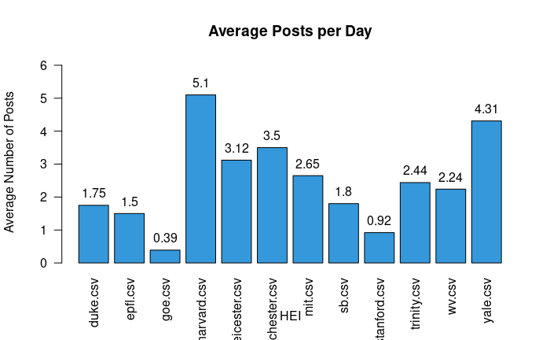

```r
barplot(posts_per_day$avg_posts_per_days,
        names.arg = posts_per_day$id,
        main = "Average Posts per Day",
        xlab = "HEI",
        ylab = "Average Number of Posts",
        ylim = c(0, max(posts_per_day$avg_posts_per_days) + 1),
        las = 2,
        col = "#3498DB")

# Adding text labels over each bar and aligning it with the center of each bar
text(x = barplot(posts_per_day$avg_posts_per_days, plot = FALSE),
     y = posts_per_day$avg_posts_per_days,
     labels = round(posts_per_day$avg_posts_per_days, 2),
     pos = 3)
```

# Plot for the average number of posts per week for each HEI

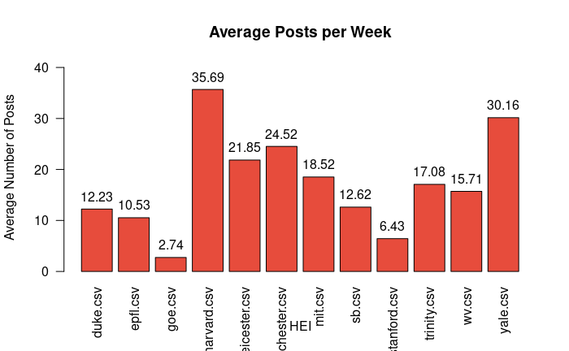

```r
barplot(posts_per_week$avg_posts_per_weeks,
        names.arg = posts_per_week$id,
        main = "Average Posts per Week",
        xlab = "HEI",
        ylab = "Average Number of Posts",
        ylim = c(0, max(posts_per_week$avg_posts_per_weeks) + 5),
        las = 2,
        col = "#E74C3C")

text(x = barplot(posts_per_week$avg_posts_per_weeks, plot = FALSE),
     y = posts_per_week$avg_posts_per_weeks,
     labels = round(posts_per_week$avg_posts_per_weeks, 2),
     pos = 3)
```

# Defining the intervals of time for the academic year

```r
intervals <- list(
  interval1 = as.POSIXct(c("2022-08-31", "2022-12-15")),
  interval2 = as.POSIXct(c("2023-01-04", "2023-04-01")),
  interval3 = as.POSIXct(c("2023-04-14", "2023-06-15"))
)
```

# Function to check if a date falls within a given interval of time and apply appropriate Boolean

```r
check_interval <- function(date) {
  for (i in 1:length(intervals)) {
    interval_start <- intervals[[i]][1]
    interval_end <- intervals[[i]][2]
    if (date >= interval_start & date <= interval_end) {
      return(TRUE)
    }
  }
  return(FALSE)
}
```

```r
data_posts$academic_year <- sapply(data_posts$created_at, check_interval)
print(data.frame(id = data_posts$id, academic_year = data_posts$academic_year))
```

| id | academic_year |
| --- | --- |
| yale.csv | FALSE |
| yale.csv | FALSE |
| yale.csv | FALSE |
| yale.csv | FALSE |
| yale.csv | FALSE |
| yale.csv | FALSE |
| yale.csv | FALSE |
| yale.csv | FALSE |
| yale.csv | FALSE |
| yale.csv | FALSE |

[output cut: 990 more lines]

# Function to count number of posts and average per day during academic time and vacation time

```r
analyze_posts <- function(academic_year_filter = TRUE) {
  # Filtering the data based on the academic_year_filter
  filtered_data <- data_posts %>%
    filter(academic_year == academic_year_filter)

  # Count of days for each HEI
  unique_days <- filtered_data %>%
    group_by(id) %>%
    summarise(unique_days = n_distinct(as.Date(created_at)))

  # Count of posts for each HEI
  number_posts_boolean <- filtered_data %>%
    group_by(id) %>%
    summarise(count = n())

  # Naming the column respecting the time period
  time <- ifelse(academic_year_filter, "academic_time", "vacation_time")
  column_name <- paste0("avg_posts_in_", time)

  # Combination of data and calculation of average posts per day
  combined_data <- left_join(unique_days, number_posts_boolean, by = "id")
  combined_data <- combined_data %>%
    mutate(!!column_name := round((count / unique_days), 2))

  print(combined_data)
  return(combined_data)
}
```

```r
data_posts_academic <- analyze_posts()
```

| id | unique_days | count | avg_posts_in_academic_time |
| --- | --- | --- | --- |
| duke.csv | 200 | 522 | 2.61 |
| epfl.csv | 182 | 443 | 2.43 |
| goe.csv | 91 | 105 | 1.15 |
| harvard.csv | 252 | 1378 | 5.47 |
| leicester.csv | 249 | 795 | 3.19 |
| manchester.csv | 232 | 892 | 3.84 |
| mit.csv | 248 | 705 | 2.84 |
| sb.csv | 225 | 511 | 2.27 |
| stanford.csv | 144 | 258 | 1.79 |
| trinity.csv | 200 | 679 | 3.40 |

[output cut: 2 more lines]

```r
data_posts_vacations <- analyze_posts(academic_year_filter = FALSE)
```

| id | unique_days | count | avg_posts_in_vacation_time |
| --- | --- | --- | --- |
| duke.csv | 85 | 168 | 1.98 |
| epfl.csv | 79 | 150 | 1.90 |
| goe.csv | 32 | 44 | 1.38 |
| harvard.csv | 140 | 638 | 4.56 |
| leicester.csv | 138 | 439 | 3.18 |
| manchester.csv | 126 | 493 | 3.91 |
| mit.csv | 131 | 341 | 2.60 |
| sb.csv | 99 | 202 | 2.04 |
| stanford.csv | 63 | 91 | 1.44 |
| trinity.csv | 113 | 283 | 2.50 |

[output cut: 2 more lines]

# Plot for the average number of posts during academic time for each HEI

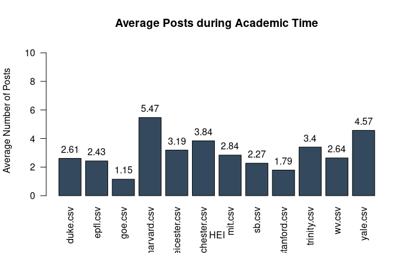

```r
barplot(data_posts_academic$avg_posts_in_academic_time,
        names.arg = data_posts_academic$id,
        main = "Average Posts during Academic Time",
        xlab = "HEI",
        ylab = "Average Number of Posts",
        ylim = c(0, max(data_posts_academic$avg_posts_in_academic_time) + 5),
        las = 2,
        col = "#34495E")

text(x = barplot(data_posts_academic$avg_posts_in_academic_time, plot = FALSE),
     y = data_posts_academic$avg_posts_in_academic_time,
     labels = round(data_posts_academic$avg_posts_in_academic_time, 2),
     pos = 3)
```

# Plot for the average number of posts during vacation time for each HEI

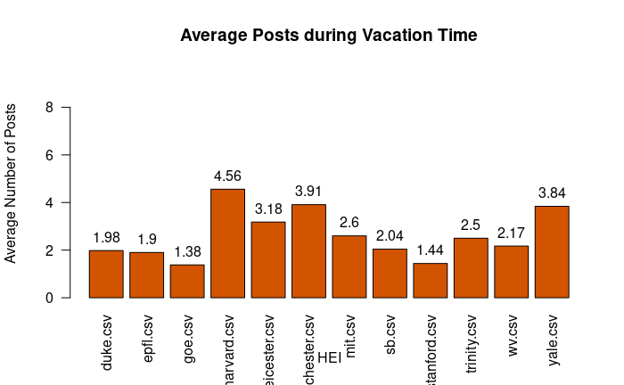

```r
barplot(data_posts_vacations$avg_posts_in_vacation_time,
        names.arg = data_posts_vacations$id,
        main = "Average Posts during Vacation Time",
        xlab = "HEI",
        ylab = "Average Number of Posts",
        ylim = c(0, max(data_posts_vacations$avg_posts_in_vacation_time) + 5),
        las = 2,
        col = "#D35400")

text(x = barplot(data_posts_vacations$avg_posts_in_vacation_time, plot = FALSE),
     y = data_posts_vacations$avg_posts_in_vacation_time,
     labels = round(data_posts_vacations$avg_posts_in_vacation_time, 2),
     pos = 3)
```

# Data preparation for dates

```r
# Creating new table that contains a new column for the day of the week
data_posts_days <- data_posts %>%
  mutate(day_of_week = weekdays(created_at))

# Selecting only the id, created_at, and day_of_week columns for the new table
data_posts_days <- data_posts_days %>%
  select(id, created_at, day_of_week)

# Create column hour from created_at
data_posts_days$created_hour <- as.numeric(format(data_posts_days$created_at, "%H"))

print(data_posts_days)
```

| id | created_at | day_of_week | created_hour |
| --- | --- | --- | --- |
| yale.csv | 2023-08-31 14:40:01 | quinta | 14 |
| yale.csv | 2023-08-31 13:33:36 | quinta | 13 |
| yale.csv | 2023-08-31 11:57:15 | quinta | 11 |
| yale.csv | 2023-08-30 14:24:30 | quarta | 14 |
| yale.csv | 2023-08-30 13:53:21 | quarta | 13 |
| yale.csv | 2023-08-30 13:38:00 | quarta | 13 |
| yale.csv | 2023-08-30 12:48:04 | quarta | 12 |
| yale.csv | 2023-08-29 14:49:00 | terça | 14 |
| yale.csv | 2023-08-29 13:30:02 | terça | 13 |
| yale.csv | 2023-08-28 13:00:11 | segunda | 13 |

[output cut: 990 more lines]

```r
# Grouping by id and day_of_week, then counting the number of posts
number_posts_days <- data_posts_days %>%
  group_by(id, day_of_week) %>%
  summarise(count = n())
# Grouping by id, day_of_week and day created at, then counting th enumber of tweets
number_posts_per_day <- data_posts_days %>%
    mutate(created_date = as.Date(created_at)) %>%
    group_by(id, day_of_week, created_date) %>%
    summarize(count = n())
# Finding for each HEI the average count of posts per day
average_number_posts_per_day <- number_posts_per_day %>%
  group_by(id, day_of_week) %>%
  summarise(average_count = round(mean(count), 2))
print(number_posts_days)
```

| id | day_of_week | count |
| --- | --- | --- |
| duke.csv | domingo | 37 |
| duke.csv | quarta | 122 |
| duke.csv | quinta | 128 |
| duke.csv | segunda | 114 |
| duke.csv | sexta | 115 |
| duke.csv | sábado | 44 |
| duke.csv | terça | 130 |
| epfl.csv | domingo | 11 |
| epfl.csv | quarta | 97 |
| epfl.csv | quinta | 139 |

[output cut: 72 more lines]

# Highest and lowest posts

```r
# Finding the HEI with the lowest count of posts per day
lowest_count <- number_posts_days %>%
  group_by(day_of_week) %>%
  slice_min(order_by = count) %>%
  select(day_of_week, id, count)

# Finding the HEI with the highest count of posts per day
highest_count <- number_posts_days %>%
  group_by(day_of_week) %>%
  slice_max(order_by = count) %>%
  select(day_of_week, id, count)

# Combine the results
high_low_HEI <- bind_rows(lowest_count, highest_count) %>%
  arrange(day_of_week)

print(high_low_HEI)
```

| day_of_week | id | count |
| --- | --- | --- |
| domingo | epfl.csv | 11 |
| domingo | harvard.csv | 231 |
| quarta | goe.csv | 31 |
| quarta | harvard.csv | 316 |
| quinta | goe.csv | 30 |
| quinta | manchester.csv | 323 |
| segunda | goe.csv | 33 |
| segunda | harvard.csv | 305 |
| sexta | goe.csv | 19 |
| sexta | harvard.csv | 311 |

[output cut: 4 more lines]

# Plot for the lowest and highest count of posts per day for each day of the week

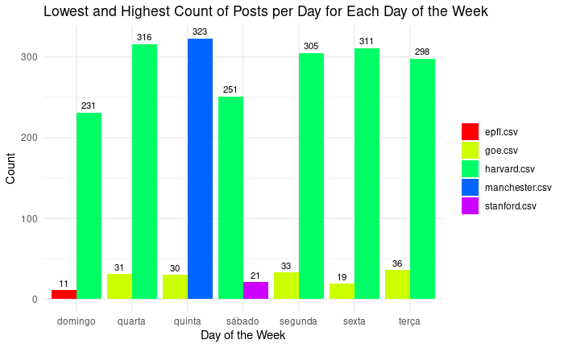

```r
ggplot(high_low_HEI, aes(x = day_of_week, y = count, fill = id)) +
  geom_bar(stat = "identity", position = "dodge") +
  geom_text(aes(label = count),
            position = position_dodge(width = 0.9),
            vjust = -0.5,
            size = 3) +
  labs(title = "Lowest and Highest Count of Posts per Day for Each Day of the Week",
       x = "Day of the Week", y = "Count") +
  scale_fill_manual(values = rainbow(length(unique(high_low_HEI$id)))) +
  theme_minimal() +
  theme(legend.title = element_blank())
```

# Average of posts

```r
# Finding the HEI with lowest and highest averaged count of posts per day
high_low_average_HEIs <- average_number_posts_per_day %>%
  group_by(day_of_week) %>%
  filter(average_count == max(average_count) | average_count == min(average_count)) %>%
  arrange(day_of_week, ifelse(average_count == min(average_count), average_count, -average_count))

print(high_low_average_HEIs)
```

| id | day_of_week | average_count |
| --- | --- | --- |
| harvard.csv | domingo | 4.28 |
| mit.csv | domingo | 1.02 |
| harvard.csv | quarta | 5.64 |
| goe.csv | quarta | 1.15 |
| manchester.csv | quinta | 6.09 |
| goe.csv | quinta | 1.20 |
| harvard.csv | segunda | 5.35 |
| goe.csv | segunda | 1.14 |
| harvard.csv | sexta | 5.55 |
| goe.csv | sexta | 1.12 |

[output cut: 4 more lines]

# Plot for the highest and lowest average count of posts per day for each day of the week

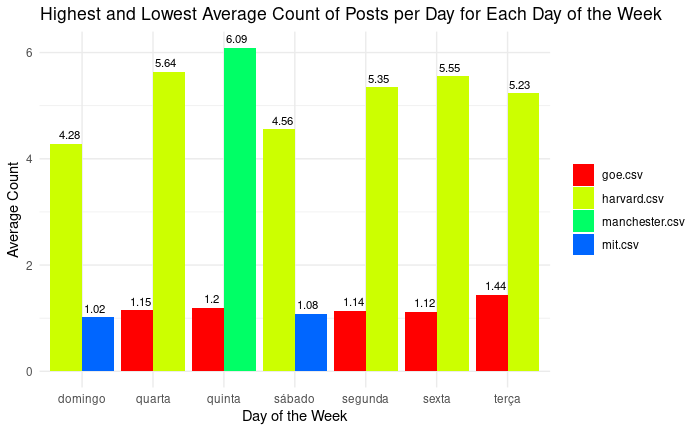

```r
ggplot(high_low_average_HEIs, aes(x = day_of_week, y = average_count, fill = id)) +
  geom_bar(stat = "identity", position = "dodge") +
  geom_text(aes(label = round(average_count, 2)),
            position = position_dodge(width = 0.7),
            vjust = -0.5,
            size = 3) +
  labs(title = "Highest and Lowest Average Count of Posts per Day for Each Day of the Week",
       x = "Day of the Week", y = "Average Count") +
  scale_fill_manual(values = rainbow(length(unique(high_low_HEI$id)))) +
  theme_minimal() +
  theme(legend.title = element_blank())
```

# Favourite hour and day

```r
favourite_day_hei <- number_posts_days %>%
  group_by(id) %>%
  top_n(1, count) %>%
  arrange(id)

print(favourite_day_hei)
```

| id | day_of_week | count |
| --- | --- | --- |
| duke.csv | terça | 130 |
| epfl.csv | quinta | 139 |
| goe.csv | terça | 36 |
| harvard.csv | quarta | 316 |
| leicester.csv | quinta | 231 |
| manchester.csv | quinta | 323 |
| mit.csv | quinta | 205 |
| sb.csv | quinta | 150 |
| stanford.csv | terça | 68 |
| trinity.csv | quinta | 223 |

[output cut: 2 more lines]

```r
number_posts_hours <- data_posts_days %>%
  group_by(id, created_hour) %>%
  summarise(count = n()) %>%
  ungroup()
favourite_hour_hei <- number_posts_hours %>%
  group_by(id) %>%
  top_n(1, count) %>%
  arrange(id)

print(favourite_hour_hei)
```

| id | created_hour | count |
| --- | --- | --- |
| duke.csv | 10 | 181 |
| epfl.csv | 11 | 69 |
| goe.csv | 12 | 36 |
| harvard.csv | 17 | 184 |
| leicester.csv | 12 | 165 |
| manchester.csv | 10 | 250 |
| mit.csv | 12 | 303 |
| sb.csv | 10 | 115 |
| stanford.csv | 17 | 47 |
| trinity.csv | 11 | 124 |

[output cut: 2 more lines]

# Function to plot heatmap for various HEIs

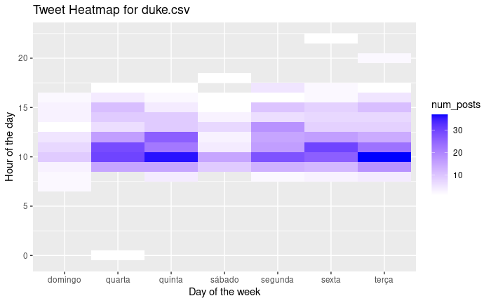

```r
heatmap_maker <- function(target_id = "duke.csv"){
  # Filtering data for the specific HEI
  target_data <- data_posts_days %>%
    filter(id == target_id)

  # Grouping by day of the week and hour, and counting the number of tweets
  tweet_counts <- target_data %>%
    group_by(day_of_week, created_hour) %>%
    summarise(num_posts = n())

  # Plotting heatmap
  ggplot(tweet_counts, aes(x = day_of_week, y = created_hour, fill = num_posts)) +
    geom_tile() +
    scale_fill_gradient(low = "white", high = "blue") +
    labs(title = paste("Tweet Heatmap for", target_id),
         x = "Day of the week",
         y = "Hour of the day")
}

heatmap_maker()
```

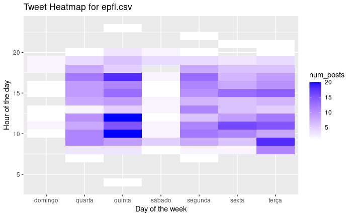

```r
heatmap_maker("epfl.csv")
```

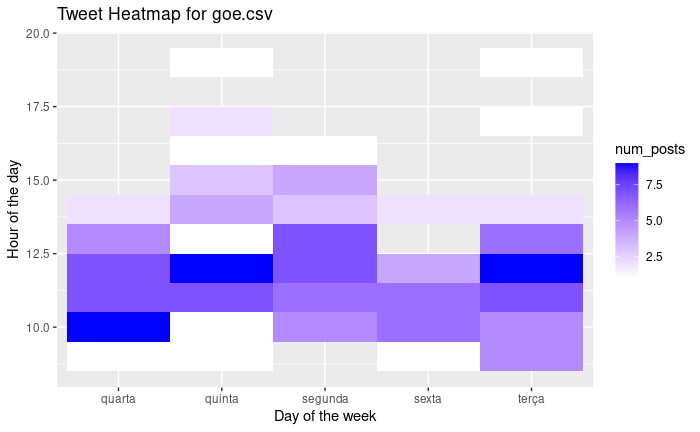

```r
heatmap_maker("goe.csv")
```

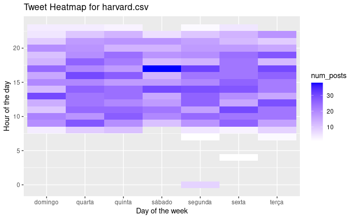

```r
heatmap_maker("harvard.csv")
```

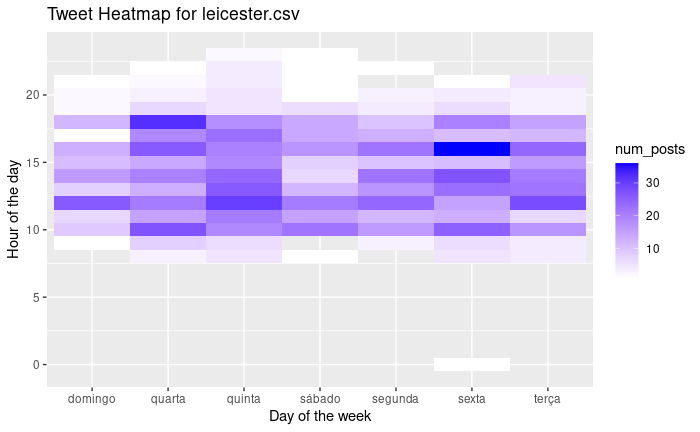

```r
heatmap_maker("leicester.csv")
```

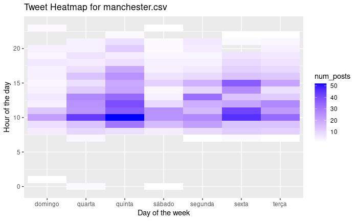

```r
heatmap_maker("manchester.csv")
```

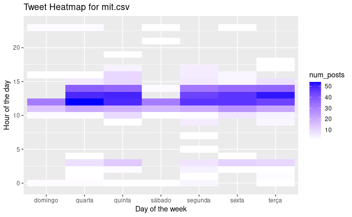

```r
heatmap_maker("mit.csv")
```

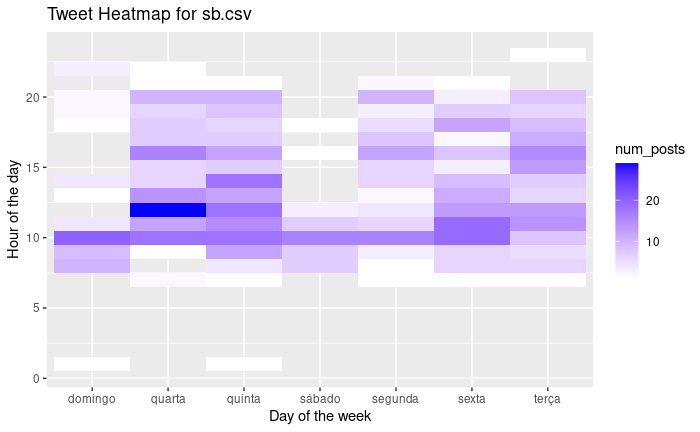

```r
heatmap_maker("sb.csv")
```

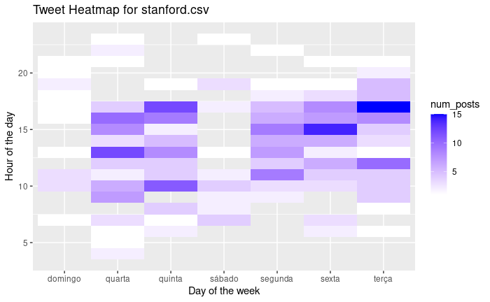

```r
heatmap_maker("stanford.csv")
```

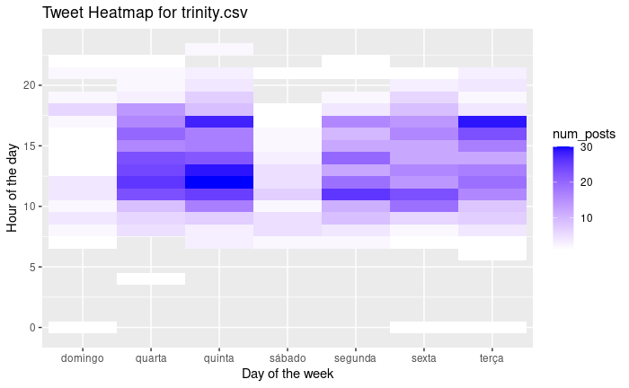

```r
heatmap_maker("trinity.csv")
```

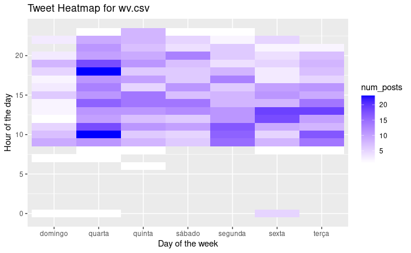

```r
heatmap_maker("wv.csv")
```

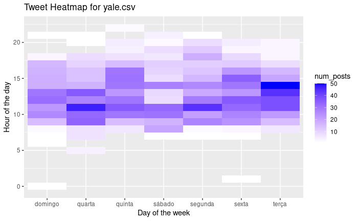

```r
heatmap_maker("yale.csv")
```

# Hashtags

```r
# Transforming empty strings into NA
data_posts$hashtags[data_posts$hashtags == ""] <- NA

# Table with number of unique hashtags and percentage of usage
hashtags <- data_posts %>%
                group_by(id) %>%
                summarise(count = n(),
                          na = sum(is.na(hashtags)),
                          unique_hashtags = length(unique(hashtags)),
                          hashtag_percentage = round(((count - na) / count * 100), 2))

print(hashtags)
```

| id | count | na | unique_hashtags | hashtag_percentage |
| --- | --- | --- | --- | --- |
| duke.csv | 690 | 653 | 20 | 5.36 |
| epfl.csv | 593 | 441 | 130 | 25.63 |
| goe.csv | 149 | 54 | 77 | 63.76 |
| harvard.csv | 2016 | 1784 | 61 | 11.51 |
| leicester.csv | 1234 | 246 | 377 | 80.06 |
| manchester.csv | 1385 | 1287 | 65 | 7.08 |
| mit.csv | 1046 | 1014 | 22 | 3.06 |
| sb.csv | 713 | 281 | 156 | 60.59 |
| stanford.csv | 349 | 303 | 17 | 13.18 |
| trinity.csv | 962 | 324 | 482 | 66.32 |

[output cut: 2 more lines]

# Plot for the count of unique hashtags for each HEI

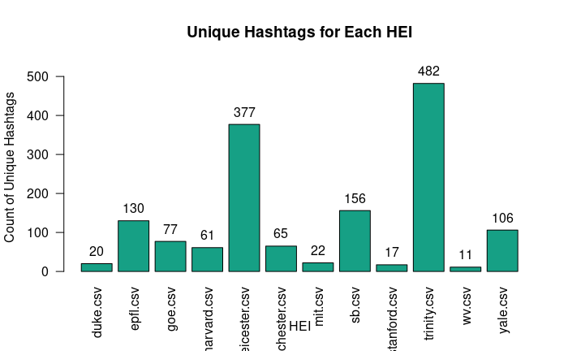

```r
barplot(hashtags$unique_hashtags,
        names.arg = hashtags$id,
        main = "Unique Hashtags for Each HEI",
        xlab = "HEI",
        ylab = "Count of Unique Hashtags",
        ylim = c(0, max(hashtags$unique_hashtags) + 50),
        las = 2,
        col= "#16A085")

text(x = barplot(hashtags$unique_hashtags, plot = FALSE),
     y = hashtags$unique_hashtags,
     labels = round(hashtags$unique_hashtags, 2),
     pos = 3)
```

# Plot for the usage of hashtag for each HEI

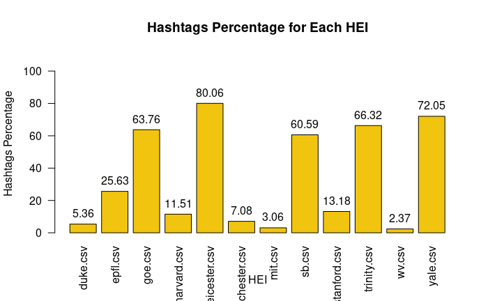

```r
barplot(hashtags$hashtag_percentage,
        names.arg = hashtags$id,
        main = "Hashtags Percentage for Each HEI",
        xlab = "HEI",
        ylab = "Hashtags Percentage",
        ylim = c(0, max(hashtags$hashtag_percentage) + 30),
        las = 2,
        col= "#F1C40F")

text(x = barplot(hashtags$hashtag_percentage, plot = FALSE),
     y = hashtags$hashtag_percentage,
     labels = round(hashtags$hashtag_percentage, 2),
     pos = 3)
```